# Exploratory Data Analysis

### Good Job! You have completed this section!

## Section 3: Aesthetics and Visuals of ggplot2

### Question 1

**The dataset is loaded for you. Perform the following tasks:**

1. Using the longley dataset, plot the relationship between Umployed and GNP.
2. As a scatter plot, plot out Unemployed values as blue dots and Employed values as green dots.
3. Create a new variable as a column known as Armed.Forces.Unemployed.Rel. In it, place a Y for when the number of armed forces are greater than unemployed and N otherwise. Plot a graph to show the relationship between unemployed and armed forces and use the Armed.Forces.Unemployed.Rel for aesthetics and color.

Add appropriate title, axis labels and charts for EACH of the above charts. You need to use ggplot2 to accomplish this task.

```r
head(longley)
```

```
##      GNP.deflator     GNP Unemployed Armed.Forces Population Year Employed
## 1947         83.0 234.289      235.6        159.0    107.608 1947   60.323
## 1948         88.5 259.426      232.5        145.6    108.632 1948   61.122
## 1949         88.2 258.054      368.2        161.6    109.773 1949   60.171
## 1950         89.5 284.599      335.1        165.0    110.929 1950   61.187
## 1951         96.2 328.975      209.9        309.9    112.075 1951   63.221
## 1952         98.1 346.999      193.2        359.4    113.270 1952   63.639
```

```r
str(longley)
```

```
## 'data.frame':    16 obs. of  7 variables:
##  $ GNP.deflator: num  83 88.5 88.2 89.5 96.2 ...
##  $ GNP         : num  234 259 258 285 329 ...
##  $ Unemployed  : num  236 232 368 335 210 ...
##  $ Armed.Forces: num  159 146 162 165 310 ...
##  $ Population  : num  108 109 110 111 112 ...
##  $ Year        : int  1947 1948 1949 1950 1951 1952 1953 1954 1955 1956 ...
##  $ Employed    : num  60.3 61.1 60.2 61.2 63.2 ...
```

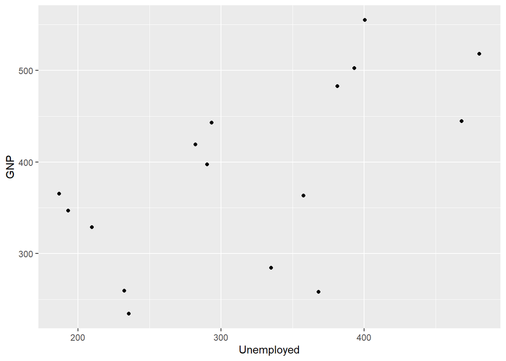

```r
library(ggplot2)
gg <- ggplot(longley, aes(Unemployed, GNP))
gg_plt <- gg + geom_point()
print(gg_plt)
```

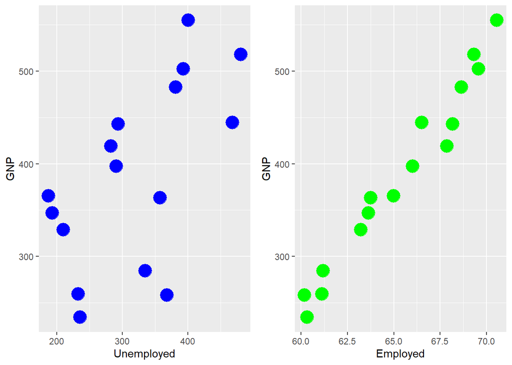

```r
gg1 <- ggplot(longley, aes(Unemployed, GNP), col(longley$Unemployed))
gg_plt1 <- gg1 + geom_point(size=6, color='blue')
#print(gg_plt1)

gg2 <- ggplot(longley, aes(Employed, GNP), col(longley$Employed))
gg_plt2 <- gg2 + geom_point(size=6, color='green')

require(gridExtra)
grid.arrange(gg_plt1, gg_plt2, ncol=2)
```

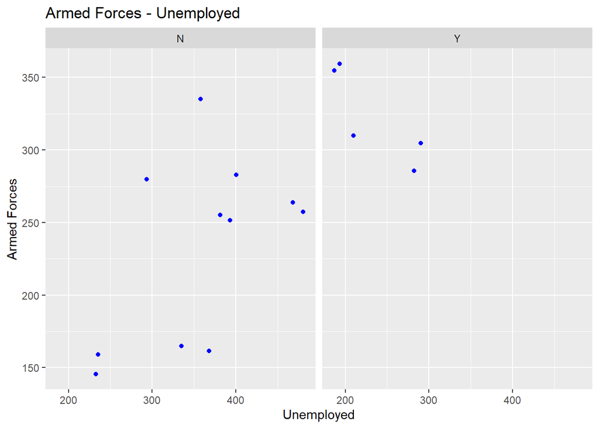

```r
library(ggplot2)

new_column <- c()
for (k in seq_along(1:length(longley$Armed.Forces)))
{
  if (longley$Armed.Forces[k] > longley$Unemployed[k])
  {
    new_column <- c(new_column, 'Y')
  }
  else
  {
    new_column <- c(new_column, 'N')
  }
}

longley$'Armed.Forces.Unemployed.Rel.' <- new_column


  plt_a <- ggplot(longley, aes(Unemployed, Armed.Forces))
  plt_b <- plt_a + geom_point(color='blue') + facet_grid(. ~ Armed.Forces.Unemployed.Rel.)
  plt_c <- plt_b + ggtitle("Armed Forces - Unemployed") +
    xlab("Unemployed") + ylab("Armed Forces")
  print(plt_c)
```

### Congratulations! You have successfully completed this course and practice exercises!